# Where Leisure Venues are in the Twin Cities: A Longitudinal Analysis

Author

Katelyn McClure & Lilabeth Sokolewicz

Published

February 12, 2026

Abstract

Arts, entertainment, and sports venues can generate economic, social, and health benefits, but their impacts depend on where they are located and how communities change around them. This study examines the spatial distribution of leisure venues across census tracts in the Twin Cities metropolitan area and how these patterns changed between 2010 and 2020. Using census tract-level data and a longitudinal generalized estimating equation model, we analyze associations between venue presence, neighborhood income, and property value. Results show that more tracts contained leisure venues in 2020 than 2010, with venue presence positively associated with property values and negatively associated with median income, highlighting potential tensions between access, economic development, and displacement.

## Introduction

Home to the well-known Guthrie Theater and US Bank Stadium, as well as local favorites like Grandview theater, the Twin Cities in Minnesota are a vibrant hub of arts, sports, and culture. But what communities are these venues located in? Why are they there? And do they have a positive or negative impact on their surroundings?

Both arts and sports are believed to increase foot traffic and provide economic and social benefits to the communities they are in. However, in practice, their effect depends heavily on their size, mission, and community context.

New sports venues are often lauded for the economic benefits they will bring to their communities; however, research suggests that sports venues actually have a negative impact on per capita income (Coates 2023). Residents who funded these venues with tax dollars may be then left with little return in employment opportunity or wages as promised. These venues can also increase nearby property values, potentially making the cost of living too expensive for current residents. Arts venues may also cause gentrification: Grodach et al. find that commercial arts venues are associated with fast-changing areas. Arts venues make an area more desirable, attracting developers and higher-income, often white, residents (Grodach, Foster, and Murdoch III 2014). Further, large institutions may serve tourists at the expense of the local community (Grodach, Foster, and Murdoch III 2014). Large, commercial arts and sports venues can be harmful to areas by raising rents and displacing low-income residents. However, fine arts establishments tend to be associated with stable, slow-growth areas.

Extensive research (Fancourt and Finn 2019) shows that arts participation promotes health and well-being across ages. Community-based arts participation and exposure fosters social cohesion, which may in turn improve well-being (Sonke et al. 2025). Public health initiatives increasingly use arts-based strategies to promote mental health and reduce inequities (Sonke et al. 2025). A 2002 Performing Arts Research Coalition survey found that 85% of Twin Cities residents agree that performing arts improve quality of life, and 92% agree that performing arts contribute to the education and development of children (Kopczynski and Hager, n.d.). In the five US metro areas they surveyed, more participants (about three-quarters) had attended a performance art event than a sporting event in the past year (Kopczynski and Hager, n.d.). Common barriers included cost of tickets, lack of time, and in some cases, difficulty in transportation or parking. Frequent performance-art attendees tended to also be more involved in the community in other ways. The arts can contribute to local economic development through jobs, sales, and public revenue, as long as community and cultural considerations are taken into account (Phillips 2004). When aligned with local values, entertainment venues can revitalize communities and build connections across class, race, and age.

Location matters - a London study showed that nearness to an opera venue was highly predictive of attendance, when combined with other demographic and economic factors (Brook 2013), which indicates that those near to leisure venues are more likely to patronize them and reap the benefits of doing so. Building on this insight, our project takes a longitudinal approach by following the same census tracts over time to examine how the presence of leisure venues and neighborhood economic characteristics evolve within places, rather than comparing different locations at a single point in time. Therefore, in this analysis, we explore how the distribution of arts, sports, and entertainment venues across the Twin Cities Metro area changes over time. Particularly, we ask: how are income and land value related to the number of leisure venues in an area, and how does that change between 2010 and 2020? The location of leisure venues can shape economic opportunity, community well-being, and patterns of neighborhood change. Understanding spatial distribution and how it changes allows us to determine which communities feel these impacts - good or bad - the most.

## Data

The data for this project subsets the *Arts, Entertainment, and Leisure* dataset from the National Neighborhood Data Archive (NaNDA), provided by the Institute for Social Research at the University of Michigan (Melendez et al. 2024). This data is aggregated across the United States by census tract, and selecting the tracts in the seven-county Twin Cities metropolitan area (Anoka, Carver, Dakota, Hennepin, Ramsey, Scott, Washington) gives us our counts for museums, performance theaters, movie theaters, zoos, aquariums, and public gardens in the years 2010 and 2020. In order to include sports venues in our definition, we manually created a census-level tract count of professional sports venues in the Twin Cities metro for 2010 and 2020 based on the Table of Professional Teams on the *Sports in Minnesota* Wikipedia article (Wikipedia contributors 2025). We combined these variables into a single binary variable that records whether a tract includes any arts, entertainment, or professional sports venue, which we define as “leisure venues.”

This data represents neighborhoods rather than individuals, with each observation corresponding to a census tract that approximates the residential context of about 4,000 people. Because measures are available for both 2010 and 2020, each tract contributes repeated observations over time, allowing us to examine changes in leisure venue presence within the same geographic areas.

To explore how neighborhood characteristics relate to the presence of these leisure venues, we integrate demographic information from the American Community Service, including measures related to income, age distribution, and racial and ethnic composition (U.S. Census Bureau 2010, 2020a). We also incorporate estimated land and building parcel values from the Minnesota Geospatial Commons MetroGIS Regional Parcel Dataset to capture economic conditions in each census tract (MetroGIS 2025). These were then aggregated to census tracts based on which tract the center of the parcel falls in. To define the geographic units for our analysis, we used 2020 Census tract shapefiles from the U.S. Census Bureau for the seven counties in the Twin Cities metropolitan area (U.S. Census Bureau 2020b). Together, this data allows us to examine how the presence of leisure venues is distributed across neighborhoods with differing economic characteristics and how those patterns changed between 2010 and 2020.

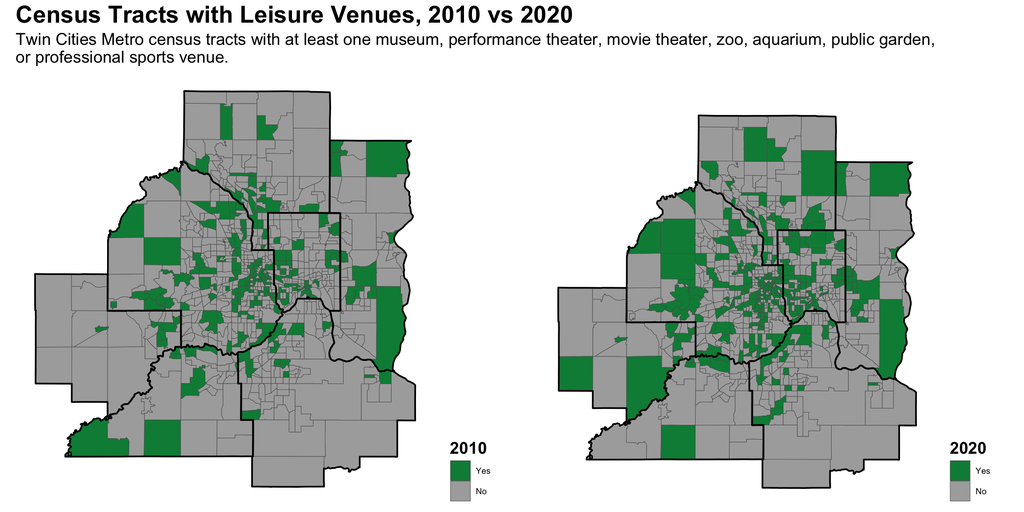

## Methods

To examine how neighborhood characteristics relate to the presence of leisure venues, we modeled census tract–level data from two time points (2010 and 2020). Our outcome of interest was a binary indicator of whether a census tract contained at least one leisure venue, defined above as an arts, entertainment, or professional sports venue.

Because our outcome is binary, we first fit a logistic regression model with median household income, average total parcel value (the combined land and building value), and year as predictors. This model serves as an initial exploratory analysis of the association between neighborhood economic characteristics and the presence of leisure venues. As the outcome is binary, model coefficients are returned as log odds.

Two features of the data complicate standard regression assumptions. First, census tracts are spatial units, and neighboring tracts may share unmeasured characteristics that influence venue placement. Second, the same tracts are observed at two time points, creating correlation across repeated measurements within tracts.

To assess spatial dependence, we examined spatial autocorrelation in the residuals from the logistic regression using Moran’s I (Moran 1950). Neighborhood structure was defined using rook contiguity, which treats census tracts that share an edge boundary as neighbors. These spatial diagnostics were implemented using the spdep package in R (Bivand et al. 2017). We also briefly explored a spatial mixed effects model that includes spatially structured random effects with a Matern covariance structure to account for potential spatial dependence between neighboring census tracts before ultimately deciding to not pursue a fully spatial modeling approach.

To account for repeated observations of census tracts over time, we fit a generalized estimating equation (GEE) model with a logistic link. The GEE framework is well suited for longitudinal data because it accounts for within-tract correlation over time while estimating population-averaged effects with robust standard errors, which provide valid inference even if the specified working correlation structure is misspecified (Liang and Zeger 1986). Census tract was specified as the clustering unit, and an exchangeable working correlation structure was used, which assumes equal correlation between observations from the same tract across time. Given that only two time points were available, this structure provided a parsimonious and appropriate modeling choice. The GEE model was fit using the geeM package in R (McDaniel, Henderson, and Rathouz 2013).

The final GEE model included median household income, average parcel value, and year as predictors, with monetary values reported per $100,000 to decrease computational intensity. Coefficient estimates from this model represent average associations between neighborhood economic characteristics and the probability that a census tract contains at least one leisure venue, after accounting for within-tract correlation over time.

All data management and visualization were conducted in R using the tidyverse (Wickham et al. 2019) and sf (Pebesma et al. 2018) packages. Census tract and county boundary shapefiles were obtained using the tigris package (Walker 2025).

## Results

Our GEE model produced statistically significant coefficient estimates, suggesting meaningful associations between the presence of leisure venues and each of year, property value, and income in a tract.

Our model estimates that, holding property value and income constant, the odds of having a leisure venue in a given tract in 2020 are about 41% higher than the odds of having a leisure venue in that tract in 2010. This indicates that more tracts have venues in 2020 than in 2010, and that, generally, more new venues are being built than are shutting down.

Accounting for year and income levels, for a $100,000 increase in average property value, we expect to see about a 36% increase in the odds of a tract having a leisure venue. This is somewhat surprising, as one might expect venues to be built where land is cheap. There is potentially reverse causality at play: the presence of a new leisure venue may raise the nearby land value itself, making it appear that it was originally built on valuable land. Yet, this is not universally true; a sports stadium is likely to make an area less desirable and lower nearby property values, whereas a theater like the Guthrie would raise them.

For a $100,000 increase in median income, holding year and property value constant, we expect about a 64% decrease in the odds of a tract having a leisure venue. Again, this is surprising - one might expect more leisure venues to be located in areas with high-income residents who have disposable income and time to attend leisure events. This could be in part due to zoning laws - there are not likely to be commercial leisure establishments in, for instance, a suburban residential neighborhood, which may have higher median income than an urban downtown district with mixed zoning. Even venues primarily attended by high-income residents are likely not built in the same tracts where they live.

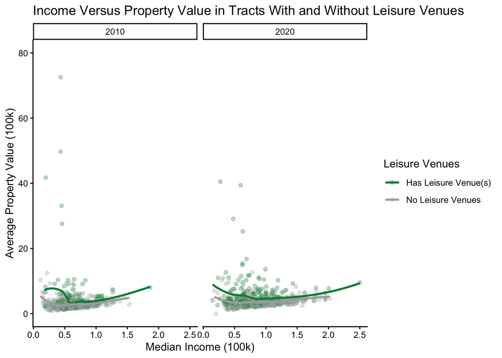

Median income and average property value are positively correlated, which makes it unexpected that they are oppositely associated with venue presence. This visualization suggests that this seemingly contradictory trend may be due to the presence of outliers. Notably, there are 5 tracts with very high average property value and low median incomes which influence this estimate. These contain regional parks, large-area spaces like zoos or golf courses, university campuses, the state capital building, and the heart of downtown St Paul (an area with 20 leisure venues). These are large and/or high value properties that drive the average property values very high, without being in high-income areas. These tracts contribute to the impression that areas with lower incomes and higher property values have higher chances of having leisure venues.

These estimates were all highly significant (p < 0.005), based on our robust standard errors, indicating strong associations between our explanatory variables and the presence of leisure venues. These relationships are positive for year and property value, and negative for median income.

## Conclusions

Our finding that more tracts have venues in 2020 than in 2010 suggests that more people are closer to leisure venues in 2020, or that access to leisure venues improves over the course of this decade. This is good in that access to some venues, like gardens or community theaters, benefit communities and improve individual well-being. However, if the new venues are highly commercial, like large sports stadiums or commercial theaters, this may be a harmful trend that indicates increasing gentrification. The positive association between property value and venue presence indeed suggests that these venues increase nearby land values, which may mean they make the area better-off economically by increasing foot traffic and patronization of nearby businesses, yet may also mean that original community members are being priced out and displaced. Finally, income being negatively associated with venue presence indicates that low-income tracts are more likely to contain leisure venue(s). This is potentially a good thing - if beneficial leisure venues are only a short distance from lower-income residents, they may have more awareness of their existence, ability to reach them, and thus access to their positive effects. If the venues are highly commercial, lower-income residents may be unable to afford access to them and suffer from disrupted communities, without necessarily reaping any economic benefits from them.

There are some important limitations to our analysis. First, we only consider two points in time, 2010 and 2020, due to limitations of data availability beginning after 2000 for parcel land value data and ACS data. Thus, we can’t know if the trends we saw in our 10-year span extend to the past, and cannot make assumptions about them continuing in the future. In considering whether a tract has a venue, we don’t distinguish between art and sports venues, which may tend to be located in different places, and have different impacts on their communities. Further, we don’t account for the commercial status or accessibility of a venue - more people can afford to go see movies at Grandview than Broadway shows at the Ordway - which affects the ways in which it impacts a community. We also do not account for entertainment events hosted outside of traditional venues, such as at schools, universities, and community centers or parks, which may be important venues of art and sports exposure for those who do not have the means or desire to attend formal events at the venues in our dataset. Further analysis considering these factors could give a more comprehensive picture of how leisure venues’ locations affect their accessibility and impacts.

Overall, our analysis demonstrates that leisure venue presence is affected differently by time, property value, and income. Access to leisure venues has the potential to improve individuals’ well-being and community connectedness, and these venues have the potential to greatly affect their surroundings. While increase in venues over time suggests expanding access, opposing associations with property value and income highlight how venue placement may both generate economic benefits and worsen displacement or unequal access.

## Acknowledgements

We are very grateful to Professor Brianna Heggeseth for teaching us all we know about correlated data and for generously offering so much support over the Fall 2025 semester and over both of our college journeys.

## References

Bivand, Roger, Micah Altman, Luc Anselin, Renato Assunção, Olaf Berke, Andrew Bernat, and Guillaume Blanchet. 2017. “Package ‘Spdep’.” *Spatial Dependence: Weighting Schemes, Statistics, R Package Version* 1 (5).

Brook, Orian. 2013. “Reframing Models of Arts Attendance: Understanding the Role of Access to a Venue. The Case of Opera in London.” *Cultural Trends* 22 (2): 97–107.

Coates, Dennis. 2023. “Growth Effects of Sports Franchises, Stadiums, and Arenas: 15 Years Later.” In *The Economic Impact of Sports Facilities, Franchises, and Events: Contributions in Honor of Robert Baade*, 59–87. Springer.

Fancourt, Daisy, and Saoirse Finn. 2019. *What Is the Evidence on the Role of the Arts in Improving Health and Well-Being? A Scoping Review*. World Health Organization. Regional Office for Europe.

Grodach, Carl, Nicole Foster, and James Murdoch III. 2014. “Gentrification and the Artistic Dividend: The Role of the Arts in Neighborhood Change.” *Journal of the American Planning Association* 80 (1): 21–35.

Kopczynski, Mary, and Mark Hager. n.d. “Performing Arts Research Coalition Community Report.”

Liang, Kung-Yee, and Scott L Zeger. 1986. “Longitudinal Data Analysis Using Generalized Linear Models.” *Biometrika* 73 (1): 13–22.

McDaniel, Lee S., Nicholas C. Henderson, and Paul J. Rathouz. 2013. “Fast Pure R Implementation of GEE: Application of the Matrix Package.” *The R Journal* 5: 181–87. https://journal.r-project.org/archive/2013-1/mcdaniel-henderson-rathouz.pdf.

Melendez, Robert, Jessica Finlay, Philippa Clarke, Grace Noppert, Lindsay Gypin, and Ellis Dyke. 2024. “National Neighborhood Data Archive (NaNDA): Arts, Entertainment, and Leisure Establishments by Census Tract and ZCTA, United States, 1990-2021.” ICPSR - Interuniversity Consortium for Political; Social Research. https://doi.org/10.3886/E209163V2.

MetroGIS. 2025. *Metro Regional Parcel Dataset*. https://gisdata.mn.gov/dataset/us-mn-state-metrogis-plan-regional-parcels.

Moran, Patrick AP. 1950. “Notes on Continuous Stochastic Phenomena.” *Biometrika* 37 (1/2): 17–23.

Pebesma, Edzer, Roger Bivand, Etienne Racine, Michael Sumner, Ian Cook, Tim Keitt, Robin Lovelace, et al. 2018. “Sf: Simple Features for r.” *R Package Version 0.6* 1.

Phillips, Rhonda. 2004. “Artful Business: Using the Arts for Community Economic Development.” *Community Development Journal* 39 (2): 112–22.

Sonke, Jill, Virginia Pesata, Aaron Colverson, Jane Morgan-Daniel, Alexandra K Rodriguez, Gray Davidson Carroll, Shanaé Burch, et al. 2025. “Relationships Between Arts Participation, Social Cohesion, and Well-Being: An Integrative Review of Evidence.” *Frontiers in Public Health* 13: 1589693.

U.S. Census Bureau. 2010. *American Community Survey 1-Year Data*. https://www.census.gov/data/developers/data-sets/acs-1year.2010.html#list-tab-843855098.

———. 2020a. *American Community Survey 1-Year Data*. https://www.census.gov/data/developers/data-sets/acs-1year.2020.html#list-tab-843855098.

———. 2020b. *TIGER/Line Shapefiles*. https://www.census.gov/geographies/mapping-files/time-series/geo/tiger-line-file.2020.html#list-tab-790442341.

Walker, Kyle. 2025. *Tigris: Load Census TIGER/Line Shapefiles*. https://github.com/walkerke/tigris.

Wickham, Hadley, Mara Averick, Jennifer Bryan, Winston Chang, Lucy D’Agostino McGowan, Romain François, Garrett Grolemund, et al. 2019. “Welcome to the Tidyverse.” *Journal of Open Source Software* 4 (43): 1686. https://doi.org/10.21105/joss.01686.

Wikipedia contributors. 2025. “Sports in Minnesota — Wikipedia, the Free Encyclopedia.” https://en.wikipedia.org/w/index.php?title=Sports_in_Minnesota&oldid=1309329971.